# DMC1 report

April Peterson

25 November 2019

# DMC1 Results

ToDo:

- attempt to supplement data with more KAZ DMC1 cell observations.
- change all the bad variable names

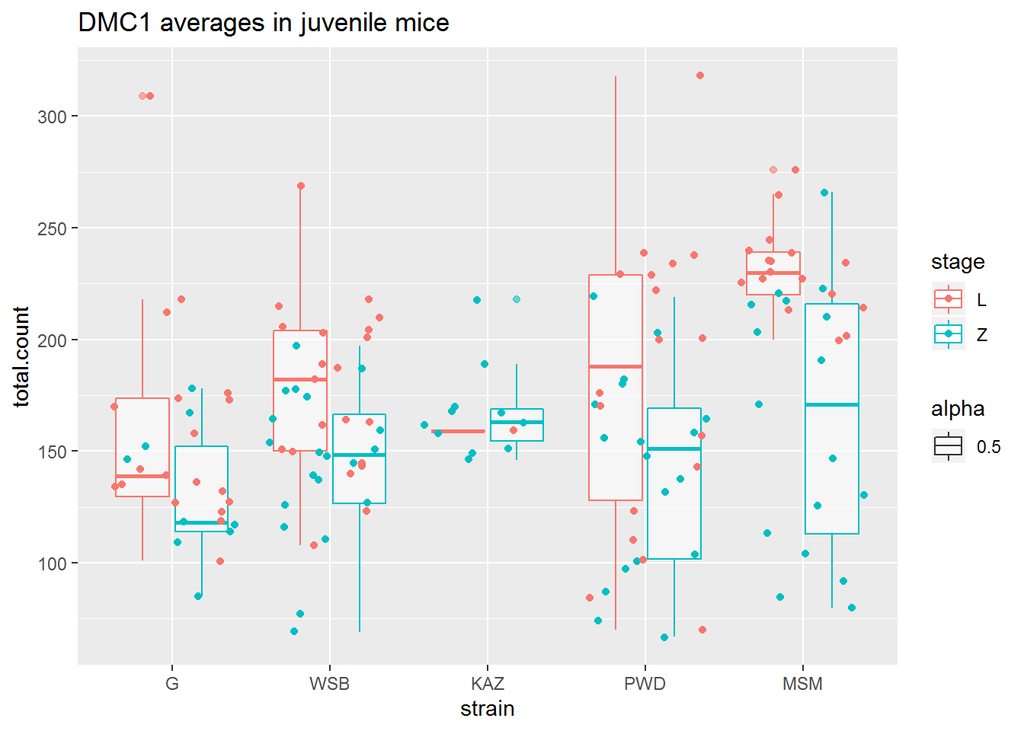

Foci of DMC1 were scored from Leptotene and Zygotene spermatocytes of juvenile mice (12-14-18 days). One mouse represents each strain. The main comparison to examine is that between the high (PWD and MSM) and low recombining (WSB, G, KAZ) strains. Since the total counts are high – we assume normality and apply t.tests

how similar are G-WSB or PWD-MSM to each other?

ToDo think of ways to add in the compared means for the high and low groups (across cell stage)

## Testing Normality

```
##
##  Bartlett test of homogeneity of variances
##
## data:  total.count by strain
## Bartlett's K-squared = 13.74, df = 4, p-value = 0.008171
```

From ANOVA analysis strain is significant for Leptotene cells but not Zygotene cells. (but take these results with a grain of salt before assumptions are tested.)

```
## Analysis of Variance Table
##
## Response: total.count
##           Df Sum Sq Mean Sq F value    Pr(>F)
## strain     4  51848 12961.9  6.1295 0.0002701 ***
## Residuals 71 150141  2114.7
## ---
## Signif. codes:  0 '***' 0.001 '**' 0.01 '*' 0.05 '.' 0.1 ' ' 1
```

```
## Analysis of Variance Table
##
## Response: total.count
##           Df Sum Sq Mean Sq F value Pr(>F)
## strain     4  12027  3006.7   1.743 0.1503
## Residuals 70 120751  1725.0
```

The two groups of mice will be split into high and low recombining groups. (to assess the patterns of variance across them)

Divide the Musculus strains into high and low recombining groups to characterize the difference in distributions. The p-values from the t.tests of the high vs low groups, indicate that the high recombining are significantly higher for the L cells (p value = 0.0021446) while the Z cells, there is not a significant difference across the high and low groups (value = 0.6627983).

## Permutations with equal sampling

The number of observations are not quite equal across strains and cell stages, so I ran permutations sampling 25 cells from the high and low recombining groups of cells.

Below are the distributions of p values for permuted t-tests from sampling 25 cells from the pooled high and low recombining groups. Permutations were done for both cell stages. The actual p value is in red.

The observed p value does not fall outside of the permuted distribution with assumes equal cell sampling.

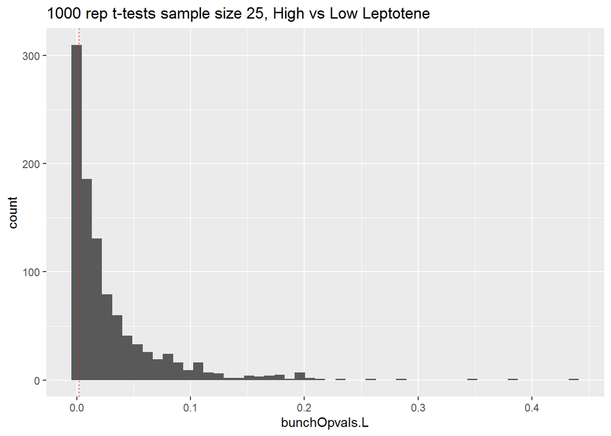

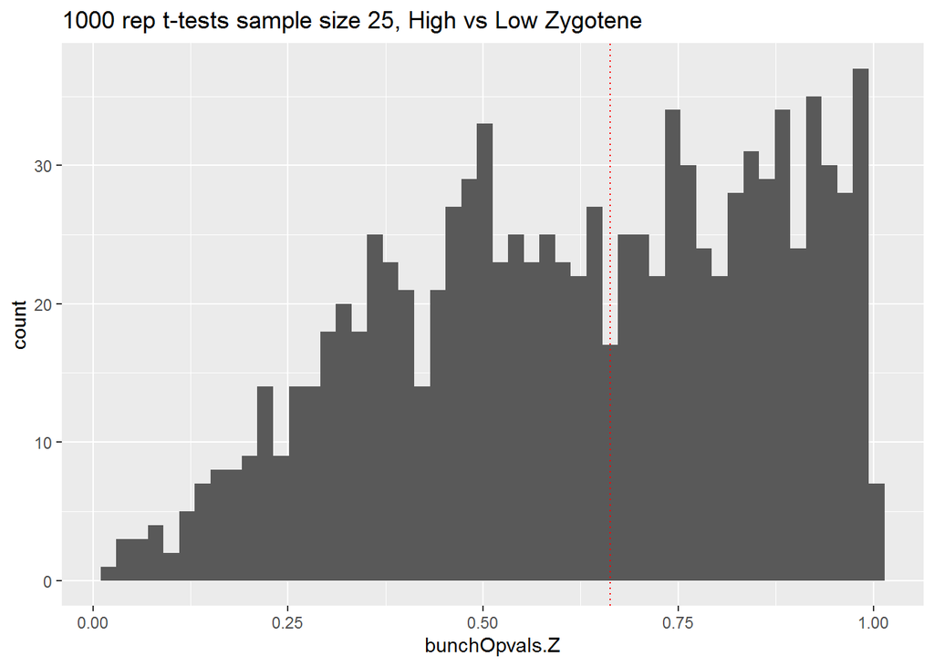

### DMC1 Correlation with MLH1

> At what stage are DMC1 foci numbers most correlated with MLH1?

The correlation with MLH1 and leptotene cells is 0.8564876.

The correlation with MLH1 and zygotene cells is 0.2793237.